# Water Potability Classification

Andrew Abeles

8/3/2021

```r
df <- read.csv("water_potability.csv")
df$Index <- 1:nrow(df)
df$Potability <- as.factor(df$Potability)
head(df)
```

```
##         ph Hardness   Solids Chloramines  Sulfate Conductivity Organic_carbon
## 1       NA 204.8905 20791.32    7.300212 368.5164     564.3087      10.379783
## 2 3.716080 129.4229 18630.06    6.635246       NA     592.8854      15.180013
## 3 8.099124 224.2363 19909.54    9.275884       NA     418.6062      16.868637
## 4 8.316766 214.3734 22018.42    8.059332 356.8861     363.2665      18.436524
## 5 9.092223 181.1015 17978.99    6.546600 310.1357     398.4108      11.558279
## 6 5.584087 188.3133 28748.69    7.544869 326.6784     280.4679       8.399735
##   Trihalomethanes Turbidity Potability Index
## 1        86.99097  2.963135          0     1
## 2        56.32908  4.500656          0     2
## 3        66.42009  3.055934          0     3
## 4       100.34167  4.628771          0     4
## 5        31.99799  4.075075          0     5
## 6        54.91786  2.559708          0     6
```

### Outliers

Let’s create some functions to help us identify outliers.

```r
z <- function(x, m, sd) { # transforms a single value into its z-score
  return((x - m) / sd)
}

is_outlier <- function(x, m, sd) { # determines whether a single value is an outlier
  z <- z(x, m, sd)
  return(abs(z) > 3)
}

outliers <- function(v) { # returns a boolean mask indicating which values in the vector are outliers
  m <- mean(v, na.rm = TRUE)
  sd <- sd(v, na.rm = TRUE)
  return(lapply(v, is_outlier, m=m, sd=sd))
}
```

Let’s use these functions to label an instance as an outlier if any of its attributes is an outlier.

```r
outlier_indices <- c() # vector to store outlier indices
for (col in colnames(df[, 1:9])) { # for each predictor column
  v <- unlist(df[c(col)]) # unlist and call it v
  indices <- filter(df, outliers(v) == TRUE)[c("Index")] # get its outliers' indices
  outlier_indices <- c(outlier_indices, indices) # append them to the global vector of outlier indices
}
outlier_indices <- unlist(outlier_indices) # flatten the list of lists into a simple vector
df$Outlier <- df$Index %in% outlier_indices # use the indices to create an outlier indicator column
filter(df, Outlier == TRUE)
```

```
##             ph  Hardness    Solids Chloramines  Sulfate Conductivity
## 1    5.6180644 304.23591 17281.975   6.1010835       NA     399.4716
## 2    5.0581089 238.56938 34873.935   8.9832761 374.4335     669.7251
## 3    1.8445384 233.76434 28689.596   7.7244323       NA     410.3873
## 4   10.1554402 300.29248 12652.363   6.6551264 398.6478     487.4591
## 5    8.5944161 270.02271 15791.675   5.9126906       NA     672.5570
## 6    6.8001191 242.00808 39143.403   9.5016946 187.1707     376.4566
## 7   13.1754017  47.43200 19237.950   8.9070197 375.1473     500.2460
## 8    6.5127371 229.26386 22475.047  12.5800265 192.0336     479.5013
## 9    5.3249419 280.08965 35344.658  13.0438061 180.2067     392.4215
## 10  10.7618978  81.71090 25999.954   8.4773939 318.4272     392.7041
## 11  10.3561188 136.32375 48621.564   9.1587039 327.9228     365.7203
## 12   3.8826311 243.80795  7751.809   0.5303513       NA     341.2911
## 13  10.0033005 143.09429 46113.957  12.9121866       NA     574.5550
## 14   8.9239806 135.93847 27919.771  12.3632848       NA     415.6295
```

[output cut: 217 more lines]

There are 115 outliers.

```r
t <- prop.table(table(df$Potability, df$Outlier))
row.names(t) <- c("Not Potable", "Potable")
colnames(t) <- c("Not Outlier", "Outlier")
t <- addmargins(A = t, FUN = list(Total = sum), quiet = TRUE)
t
```

```
##
##               Not Outlier    Outlier      Total
##   Not Potable  0.59523810 0.01465201 0.60989011
##   Potable      0.36965812 0.02045177 0.39010989
##   Total        0.96489621 0.03510379 1.00000000
```

The 115 outliers make up 3.5% of the dataset. The outliers’ Potability class balance is almost the inverse of the non-outliers’.

### Missing Values

```r
colSums(is.na(df))
```

```
##              ph        Hardness          Solids     Chloramines         Sulfate
##             491               0               0               0             781
##    Conductivity  Organic_carbon Trihalomethanes       Turbidity      Potability
##               0               0             162               0               0
##           Index         Outlier
##               0               0
```

ph, Sulfate, and Trihalomethanes have missing values. They are not correlated with other attributes and their distributions are approximately normal so let’s just replace their missing values with their non-outlier means.

```r
df_no_outliers <- filter(df, Outlier == FALSE)
df$ph[is.na(df$ph)] <- mean(df_no_outliers$ph, na.rm = TRUE)
df$Sulfate[is.na(df$Sulfate)] <- mean(df_no_outliers$Sulfate, na.rm = TRUE)
df$Trihalomethanes[is.na(df$Trihalomethanes)] <- mean(df_no_outliers$Trihalomethanes, na.rm = TRUE)
colSums(is.na(df))
```

```
##              ph        Hardness          Solids     Chloramines         Sulfate
##               0               0               0               0               0
##    Conductivity  Organic_carbon Trihalomethanes       Turbidity      Potability
##               0               0               0               0               0
##           Index         Outlier
##               0               0
```

There are no more missing values.

```r
write.csv(df, "water_potability_clean.csv", row.names = FALSE)
```

### Train Test Split

```r
set.seed(7)
n <- dim(df)[1]
idx <- runif(n) < 0.8
df_train <- df[ idx, ]
df_test <- df[ !idx, ]
```

### Scale Data

```r
y_train <- df_train$Potability
X_train <- df_train[, 1:9]
X_train <- as.data.frame(scale(X_train))
y_test <- df_test$Potability
X_test <- df_test[, 1:9]
X_test <- as.data.frame(scale(X_test))
baseline_accuracy <- length(y_test[ y_test == 0 ]) / length(y_test)
baseline_accuracy
```

```
## [1] 0.6009105
```

### Model

#### KNN (Including Outliers)

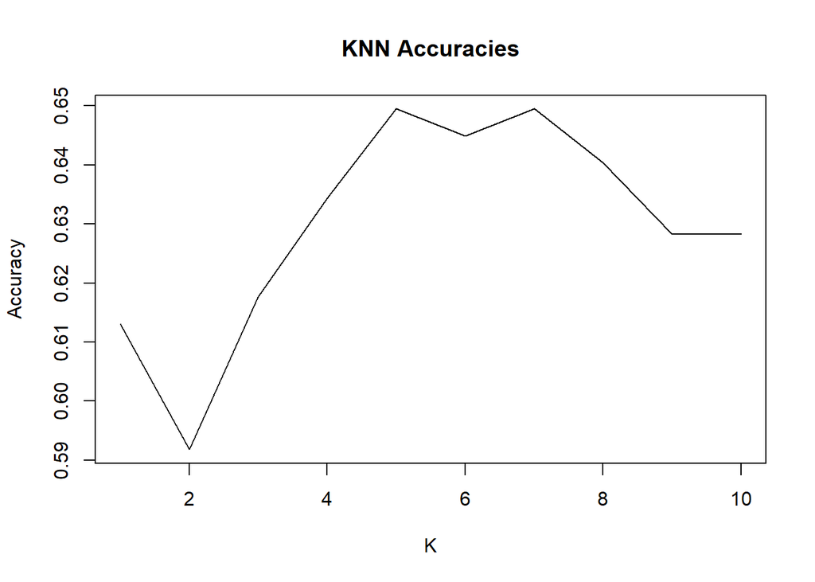

```r
accuracies <- c()
for (k in 1:10) { # for each value of K between 1 and 10
  knn <- knn( # train a KNN model
    train = X_train,
    test = X_test,
    cl = y_train,
    k = k
  )
  cm <- as.matrix(table(Actual = y_test, Predict = knn)) # get its confusion matrix
  accuracy <- sum(diag(cm)) / length(y_test) # derive its accuracy from its confusion matrix
  accuracies <- append(accuracies, accuracy) # append its accuracy to the list
}
plot( # plot the accuracy for each value of K
  x = 1:10,
  y = accuracies,
  type = "l",
  xlab = "K",
  ylab = "Accuracy",
  main = "KNN Accuracies"
)
```

K = 5 seems to be the best model in terms of accuracy. Let’s train a KNN model with K = 5 and calculate its confusion matrix.

```r
knn <- knn(
  train = X_train,
  test = X_test,
  cl = y_train,
  k = 5
)
cm <- as.matrix(table(Actual = y_test, Predicted = knn))
cm <- addmargins(A = cm, FUN = list(Total = sum), quiet = TRUE)
cm
```

```
##        Predicted
## Actual    0   1 Total
##   0     330  66   396
##   1     165  98   263
##   Total 495 164   659
```

Let’s use the confusion matrix to derive performance metrics.

```r
GT <- cm[3, 3] # grand total
TP <- cm[2, 2] # true positives
TN <- cm[1, 1] # true negatives
FP <- cm[1, 2] # false positives
FN <- cm[2, 1] # false negatives
TAP <- cm[2, 3] # total actual positives
TAN <- cm[1, 3] # total actual negatives
TPP <- cm[3, 2] # total predicted positives
TPN <- cm[3, 1] # total predicted negatives
```

```r
accuracy <- (TP + TN) / GT
precision <- TP / TPP
recall <- TP / TAP
specificity <- TN / TAN
F1_score <- 2 * (precision * recall) / (precision + recall)
accuracy
```

```
## [1] 0.6494689
```

```r
precision
```

```
## [1] 0.597561
```

```r
recall
```

```
## [1] 0.3726236
```

```r
specificity
```

```
## [1] 0.8333333
```

```r
F1_score
```

```
## [1] 0.4590164
```

#### KNN (Excluding Outliers)

##### Train Test Split

```r
df_no_outliers <- filter(df, Outlier == FALSE)
n <- dim(df_no_outliers)[1]
idx <- runif(n) < 0.8
df_train <- df_no_outliers[ idx, ]
df_test <- df_no_outliers[ !idx, ]
```

##### Scale Data

```r
y_train <- df_train$Potability
X_train <- df_train[, 1:9]
X_train <- as.data.frame(scale(X_train))
y_test <- df_test$Potability
X_test <- df_test[, 1:9]
X_test <- as.data.frame(scale(X_test))
baseline_accuracy <- length(y_test[ y_test == 0 ]) / length(y_test)
baseline_accuracy
```

```
## [1] 0.6196513
```

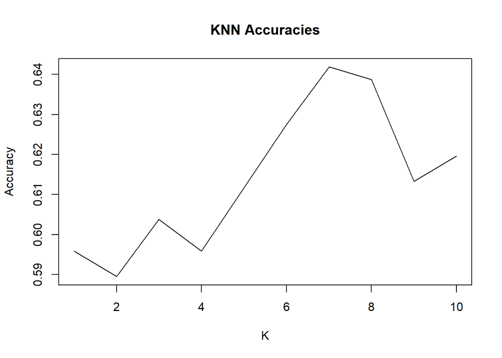

```r
accuracies <- c()
for (k in 1:10) { # for each value of K between 1 and 10
  knn <- knn( # train a KNN model
    train = X_train,
    test = X_test,
    cl = y_train,
    k = k
  )
  cm <- as.matrix(table(Actual = y_test, Predict = knn)) # get its confusion matrix
  accuracy <- sum(diag(cm)) / length(y_test) # derive its accuracy from its confusion matrix
  accuracies <- append(accuracies, accuracy) # append its accuracy to the list
}
plot( # plot the accuracy for each value of K
  x = 1:10,
  y = accuracies,
  type = "l",
  xlab = "K",
  ylab = "Accuracy",
  main = "KNN Accuracies"
)
```

K = 7 seems to be the best model in terms of accuracy. Let’s train a KNN model with K = 7 and calculate its confusion matrix.

```r
knn <- knn(
  train = X_train,
  test = X_test,
  cl = y_train,
  k = 7
)
cm <- as.matrix(table(Actual = y_test, Predicted = knn))
cm <- addmargins(A = cm, FUN = list(Total = sum), quiet = TRUE)
cm
```

```
##        Predicted
## Actual    0   1 Total
##   0     315  76   391
##   1     150  90   240
##   Total 465 166   631
```

Let’s use the confusion matrix to derive performance metrics.

```r
GT <- cm[3, 3] # grand total
TP <- cm[2, 2] # true positives
TN <- cm[1, 1] # true negatives
FP <- cm[1, 2] # false positives
FN <- cm[2, 1] # false negatives
TAP <- cm[2, 3] # total actual positives
TAN <- cm[1, 3] # total actual negatives
TPP <- cm[3, 2] # total predicted positives
TPN <- cm[3, 1] # total predicted negatives
```

```r
accuracy <- (TP + TN) / GT
precision <- TP / TPP
recall <- TP / TAP
specificity <- TN / TAN
F1_score <- 2 * (precision * recall) / (precision + recall)
accuracy
```

```
## [1] 0.6418384
```

```r
precision
```

```
## [1] 0.5421687
```

```r
recall
```

```
## [1] 0.375
```

```r
specificity
```

```
## [1] 0.8056266
```

```r
F1_score
```

```
## [1] 0.4433498
```

The model performs better when outliers are included.